# An introduction to harp

Andrew Singleton

SUV verifikasjonsmøte 19 March 2021

## **What is harp?**

- A “framework” for working with meteorological / climatological data in R
- Comprises several packages:
  - harpIO - for reading / writing data
  - harpPoint - for point verification
  - harpSpatial - for spatial verification
  - harpVis - for visualization
  - (harpMethods) - for underlying classes, methods and common functionality
  - harp - meta package for functionality that includes more than 1 harp pacakge
  - harpData - for example data

## **Philisophy**

- harp is built with “tidy” data principles in mind
- No matter where the data come from or what they represent the structure is (nearly) always the same
  - Data are stored as data frames
  - Every column is a “variable”
  - Every row is an “observation”
  - Every cell is a “value”
- Designed to integrate with the “tidyverse” in R
  - data wrangling with *dplyr* and *tidyr* verbs
  - plotting with *ggplot2* (where appropriate)
  - functional programming with *purrr*

## **Installation**

- The harp code is stored on Github under “harphub”
- Can be installed in R with the following:

```r
install.packages("remotes")
library(remotes)
install_github("harphub/harp")
```

- Installation can take some time as harp has many (too many?) dependencies

## **Reading forecast data**

`read_forecast()` can be used to read forecasts from any file format.

```r
library(harp)

read_forecast(
  start_date,
  end_date,
  fcst_model,
  (parameter),
  (file_path),
  (file_template),
  (file_format_opts),
  (lead_time),
  (members)
)
```

## File name templates

- File names for `read_forecast()` are generated from templates. Dynamic parts of the file name are in { }

```r
file_path  <- "/my/path"
fcst_model <- "MEPS"
start_date <- 2021031900
end_date   <- 2021031912
by         <- "6h"
lead_time  <- seq(0, 3, 3)
members    <- c(0, 2)
template   <- "{fcst_model}/{YYYY}/{MM}/{DD}/{fcst_model}_fc{YYYY}{MM}{DD}T{HH}Z_mbr{MBR3}+{LDT3}"
```

## File name templates

- File names for `read_forecast()` are generated from templates. Dynamic parts of the file name are in { }

```r
file_path  <- "/my/path"
fcst_model <- "MEPS"
start_date <- 2021031900
end_date   <- 2021031912
by         <- "6h"
lead_time  <- seq(0, 3, 3)
members    <- c(0, 2)
template   <- "{fcst_model}/{YYYY}/{MM}/{DD}/{fcst_model}_fc{YYYY}{MM}{DD}T{HH}Z_mbr{MBR3}+{LDT3}"
```

[output not shown]

## Built in templates

- For “known” file name structures there are built in templates

```r
show_file_templates()
```

```
## # A tibble: 33 x 2
##    template_name        template
##    <chr>                <chr>
##  1 arome_arctic_extrac… /lustre/storeB/immutable/archive/projects/metproduction…
##  2 arome_arctic_full    /lustre/storeB/immutable/archive/projects/metproduction…
##  3 arome_arctic_sfx     /lustre/storeB/immutable/archive/projects/metproduction…
##  4 fctable              {file_path}/{fcst_model}/{YYYY}/{MM}/FCTABLE_{parameter…
##  5 fctable_det          {file_path}/{det_model}/{YYYY}/{MM}/FCTABLE_{parameter}…
##  6 fctable_eps          {file_path}/{eps_model}/{YYYY}/{MM}/FCTABLE_{parameter}…
##  7 fctable_eps_all_cyc… {file_path}/{eps_model}/{YYYY}/{MM}/FCTABLE_{parameter}…
##  8 fctable_eps_all_lea… {file_path}/{eps_model}/{YYYY}/{MM}/FCTABLE_{parameter}…
##  9 glameps_grib         {file_path}/{eps_model}/{sub_model}/{YYYY}/{MM}/{DD}/{H…
## 10 harmoneps_grib       {file_path}/{YYYY}/{MM}/{DD}/{HH}/mbr{MBR3}/fc{YYYY}{MM…
## 11 harmoneps_grib_fp    {file_path}/{YYYY}/{MM}/{DD}/{HH}/mbr{MBR3}/fc{YYYY}{MM…
## 12 harmoneps_grib_sfx   {file_path}/{YYYY}/{MM}/{DD}/{HH}/mbr{MBR3}/fc{YYYY}{MM…
```

[output cut: 21 more lines]

## Built in templates

- To show a full template, pass the row from the output to `show_file_templates()`.

```r
show_file_templates(21)
##
## template_name:
##  meps_lagged_6h_subset
##
## template:
##  /lustre/storeB/immutable/archive/projects/metproduction/MEPS/{YYYY}/{MM}/{DD}/meps_lagged_6_h_subset_2_5km_{YYYY}{MM}{DD}T{HH}Z.nc
```

## The `harp_fcst` object

- The output of `read_forecast()` is a `harp_fcst` object - named list of data frames - one for each `fcst_model`

```r
fcst <- read_forecast(
  2021031200,
  2021031212,
  "MEPS",
  "Pcp",
  lead_time        = seq(12, 24, 12),
  members          = c(0, 10, 20),
  file_template    = "meps_lagged_6h_subset",
  file_format_opts = netcdf_opts("met_norway_eps"),
  show_progress    = TRUE,
  return_data      = TRUE
)
```

## The `harp_fcst` object

```
## ● MEPS
## # A tibble: 6 x 11
##   fcdate              lead_time parameter validdate           level_type level
##   <dttm>                  <dbl> <chr>     <dttm>              <chr>      <dbl>
## 1 2021-03-12 00:00:00        12 Pcp       2021-03-12 12:00:00 unknown        0
## 2 2021-03-12 00:00:00        24 Pcp       2021-03-13 00:00:00 unknown        0
## 3 2021-03-12 06:00:00        12 Pcp       2021-03-12 18:00:00 unknown        0
## 4 2021-03-12 06:00:00        24 Pcp       2021-03-13 06:00:00 unknown        0
## 5 2021-03-12 12:00:00        12 Pcp       2021-03-13 00:00:00 unknown        0
## 6 2021-03-12 12:00:00        24 Pcp       2021-03-13 12:00:00 unknown        0
## # … with 5 more variables: units <chr>, fcst_cycle <chr>,
## #   MEPS_mbr000 <geolist>, MEPS_mbr010 <geolist>, MEPS_mbr020 <geolist>
```

## `dplyr` verbs on `harp_fcst` objects

```r
fcst %>%
  select(fcdate, lead_time, starts_with("MEPS"))
## ● MEPS
## # A tibble: 6 x 5
##   fcdate              lead_time MEPS_mbr000      MEPS_mbr010     MEPS_mbr020
##   <dttm>                  <dbl> <geolist>        <geolist>       <geolist>
## 1 2021-03-12 00:00:00        12 <geofield [949 … <geofield [949… <geofield [949…
## 2 2021-03-12 00:00:00        24 <geofield [949 … <geofield [949… <geofield [949…
## 3 2021-03-12 06:00:00        12 <geofield [949 … <geofield [949… <geofield [949…
## 4 2021-03-12 06:00:00        24 <geofield [949 … <geofield [949… <geofield [949…
## 5 2021-03-12 12:00:00        12 <geofield [949 … <geofield [949… <geofield [949…
## 6 2021-03-12 12:00:00        24 <geofield [949 … <geofield [949… <geofield [949…
```

```r
fcst %>%
  select(fcdate, lead_time, MEPS_mbr000) %>%
  filter(lead_time == 12)
## ● MEPS
## # A tibble: 3 x 3
##   fcdate              lead_time MEPS_mbr000
##   <dttm>                  <dbl> <geolist>
## 1 2021-03-12 00:00:00        12 <geofield [949 × 1,069]>
## 2 2021-03-12 06:00:00        12 <geofield [949 × 1,069]>
## 3 2021-03-12 12:00:00        12 <geofield [949 × 1,069]>
```

## Plotting a field

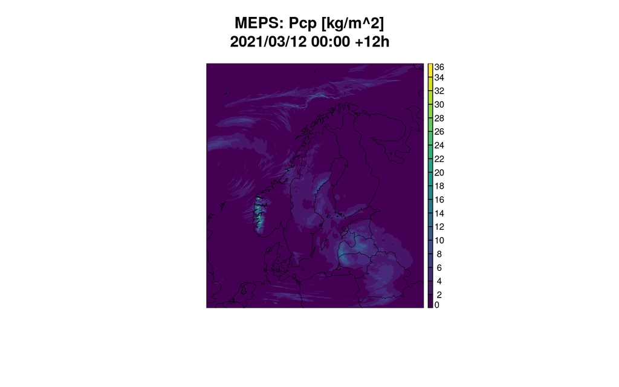

```r
plot_field(
  fcst, fcst_model = "MEPS", plot_col = MEPS_mbr000,
  fcdate = 2021031200, lead_time = 12
)
```

## Plotting a field

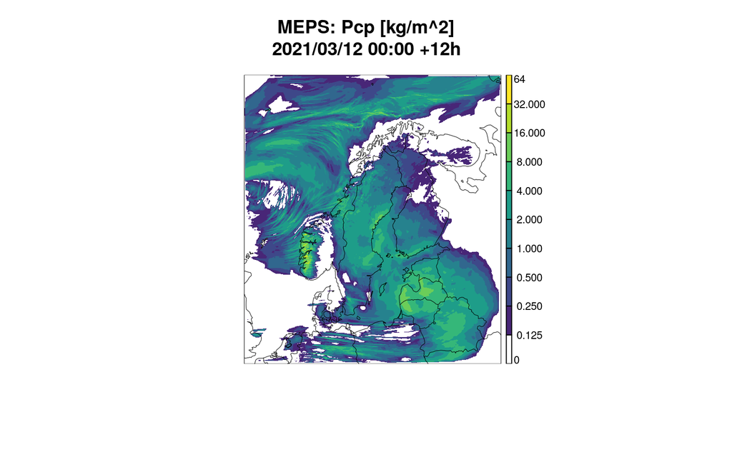

```r
plot_field(
  fcst, fcst_model = "MEPS", plot_col = MEPS_mbr000,
  fcdate = 2021031200, lead_time = 12,
  palette = c("transparent", viridis::viridis(255)),
  breaks = c(0, 0.125, 0.25, 0.5, 1, 2, 4, 8, 16, 32, 64)
)
```

## Transformations

- `read_forecast()` can transform the data by interpolating to points, to a new grid (and / or projection), or to a vertical cross section (soonish!)

```r
fcst <- read_forecast(
  2021031200,
  2021031212,
  c("MEPS", "AROME_ARCTIC"),
  "T2m",
  lead_time        = seq(0, 12, 3),
  file_template    = list(
    MEPS         = "meps_det",
    AROME_ARCTIC = "arome_arctic_extracted"
  ),
  file_format_opts = netcdf_opts("met_norway_det"),
  transformation   = "interpolate",
  show_progress    = TRUE,
  return_data      = TRUE
)
```

## Interpolated data

```r
fcst %>%
  select(fcdate, lead_time, SID, ends_with("_det"))
## ● AROME_ARCTIC
## # A tibble: 3,630 x 4
##    fcdate              lead_time   SID AROME_ARCTIC_det
##    <dttm>                  <dbl> <int>            <dbl>
##  1 2021-03-12 00:00:00         0  1001             269.
##  2 2021-03-12 00:00:00         0  1010             273.
##  3 2021-03-12 00:00:00         0  1014             271.
##  4 2021-03-12 00:00:00         0  1015             272.
##  5 2021-03-12 00:00:00         0  1018             268.
##  6 2021-03-12 00:00:00         0  1023             267.
##  7 2021-03-12 00:00:00         0  1025             271.
##  8 2021-03-12 00:00:00         0  1026             270.
##  9 2021-03-12 00:00:00         0  1027             271.
## 10 2021-03-12 00:00:00         0  1028             266.
## # … with 3,620 more rows
##
## ● MEPS
## # A tibble: 20,895 x 4
##    fcdate              lead_time   SID MEPS_det
##    <dttm>                  <dbl> <int>    <dbl>
##  1 2021-03-12 00:00:00         0  1001     271.
##  2 2021-03-12 00:00:00         0  1010     273.
##  3 2021-03-12 00:00:00         0  1014     271.
##  4 2021-03-12 00:00:00         0  1015     272.
##  5 2021-03-12 00:00:00         0  1018     269.
##  6 2021-03-12 00:00:00         0  1023     267.
##  7 2021-03-12 00:00:00         0  1025     270.
##  8 2021-03-12 00:00:00         0  1026     270.
##  9 2021-03-12 00:00:00         0  1027     270.
## 10 2021-03-12 00:00:00         0  1028     266.
## # … with 20,885 more rows
```

## Saving interpolated data

- It takes a long time to read and interpolate full model fields, so the interpolated data can be saved to SQLite files
- Simply add `output_file_opts = sqlite_opts(path = <path>)`

```r
read_forecast(
  2021031200,
  2021031212,
  c("MEPS", "AROME_ARCTIC"),
  "T2m",
  lead_time        = seq(0, 12, 3),
  file_template    = list(
    MEPS         = "meps_det",
    AROME_ARCTIC = "arome_arctic_extracted"
  ),
  file_format_opts = netcdf_opts("met_norway_det"),
  transformation   = "interpolate",
  output_file_opts = sqlite_opts(path = "/path/to/output"),
  show_progress    = TRUE
)
```

## Reading the interpolated forecasts

- The function `read_point_forecast()` is used to read interpolated data

```r
fcst <- read_point_forecast(
  2021031200,
  2021031212,
  fcst_model = c("MEPS", "AROME_ARCTIC"),
  fcst_type  = "det",
  parameter  = "T2m",
  file_path  = "suv_verifikasjonsmøte_202103"
)
```

## Reading the interpolated forecasts

```r
fcst %>%
  select(fcdate, leadtime, SID, ends_with("det"))
## ● MEPS
## # A tibble: 20,895 x 4
##    fcdate              leadtime   SID MEPS_det
##    <dttm>                 <int> <int>    <dbl>
##  1 2021-03-12 00:00:00        0  1001     271.
##  2 2021-03-12 00:00:00        0  1010     273.
##  3 2021-03-12 00:00:00        0  1014     271.
##  4 2021-03-12 00:00:00        0  1015     272.
##  5 2021-03-12 00:00:00        0  1018     269.
##  6 2021-03-12 00:00:00        0  1023     267.
##  7 2021-03-12 00:00:00        0  1025     270.
##  8 2021-03-12 00:00:00        0  1026     270.
##  9 2021-03-12 00:00:00        0  1027     270.
## 10 2021-03-12 00:00:00        0  1028     266.
## # … with 20,885 more rows
##
## ● AROME_ARCTIC
## # A tibble: 3,630 x 4
##    fcdate              leadtime   SID AROME_ARCTIC_det
##    <dttm>                 <int> <int>            <dbl>
##  1 2021-03-12 00:00:00        0  1001             269.
##  2 2021-03-12 00:00:00        0  1010             273.
##  3 2021-03-12 00:00:00        0  1014             271.
##  4 2021-03-12 00:00:00        0  1015             272.
##  5 2021-03-12 00:00:00        0  1018             268.
##  6 2021-03-12 00:00:00        0  1023             267.
##  7 2021-03-12 00:00:00        0  1025             271.
##  8 2021-03-12 00:00:00        0  1026             270.
##  9 2021-03-12 00:00:00        0  1027             271.
## 10 2021-03-12 00:00:00        0  1028             266.
## # … with 3,620 more rows
```

## Observations

- harp is designed to work with `vobs` data
  - text files used with “monitor” for operational verification in HIRLAM institutes
  - available on:
    - ecgb at `/scratch/ms/dk/nhz/oprint/OBS4`
    - lustre for AROME-ARCTIC
    - Extreme security metcoop servers for MEPS (Also in SQLite)
- Interface with `frost` coming soon(ish) [based on miIO]
- Convert `vobs` to `SQLite` with `read_obs_convert()`
- Read observations from `SQLite` with `read_point_obs()`

## Point verification workflow

- Read forecasts
- Read observations
- Join
- Verify
- Visualize

## Point verification workflow

- Read forecasts : `read_point_forecast()`
- Read observations
- Join
- Verify
- Visualize

## Point verification workflow

- Read forecasts : `read_point_forecast()`
- Read observations : `read_point_obs()`
- Join
- Verify
- Visualize

## Point verification workflow

- Read forecasts : `read_point_forecast()`
- Read observations : `read_point_obs()`
- Join : `join_to_forecast()`
- Verify
- Visualize

## Point verification workflow

- Read forecasts : `read_point_forecast()`
- Read observations : `read_point_obs()`
- Join : `join_to_forecast()`
- Verify : `det_verify()` / `ens_verify()`
- Visualize

## Point verification workflow

- Read forecasts : `read_point_forecast()`
- Read observations : `read_point_obs()`
- Join : `join_to_forecast()`
- Verify : `det_verify()` / `ens_verify()`
- Visualize : `plot_point_verif()`

## Point verification workflow

- Read forecasts : `read_point_forecast()`
- Read observations : `read_point_obs()`
- Join : `join_to_forecast()`
- Verify : `det_verify()` / `ens_verify()`
- Visualize : `plot_point_verif()`
- Save : `save_point_verif()`
- Explore : `shiny_plot_point_verif()`

## Demonstration

## Resources

https://harphub.github.io/harp_presentations/suv_verif_202103.html

- [harp website](https://harphub.github.io/harp)
- [harp tutorial](https://harphub.github.io/harp_tutorial)
- [R for Data Science](https://r4ds.had.co.nz/)